# Preterm Birth

Using Random Forest to Predict Preterm births among women in rural settings of Uganda.

Mercy Consolate Akello

2023-10-23

# Load data

```r
library(readr)
Pretem <- read_csv("C:/Users/Akello_Mercy/Desktop/wwcode hackathon/preterm.csv")
Preterm=Pretem
```

# load required packages

```r
library(dplyr)
library(tidyr)
library(lubridate)
library(ggplot2)
library(forcats)
library(stringr)
```

## Inspect data

```r
glimpse(Preterm)
```

```
## Rows: 1,883
## Columns: 25
## $ id                   <dbl> 1, 2, 3, 4, 5, 6, 7, 8, 9, 10, 11, 12, 13, 14, 15…
## $ preterm              <dbl> 0, 0, 0, 0, 0, 0, 0, 0, 0, 0, 0, 0, 1, 1, 0, 0, 0…
## $ mothers.age          <dbl> 35, 24, 31, 21, 17, 37, 18, 37, 31, 46, 28, 31, 3…
## $ attended.school      <chr> "YES", "YES", "YES", "YES", "YES", "YES", "YES", …
## $ education            <chr> "PRIMARY", "SECONDARY", "PRIMARY", "PRIMARY", "PR…
## $ religion             <chr> "Protestant", "Catholic", "Muslim", "Muslim", "Mu…
## $ ethinicity           <chr> "Basoga", "Basoga", "Basoga", "Basoga", "Basoga",…
## $ attended.anc         <chr> "YES", "YES", "YES", "YES", "YES", "YES", "YES", …
## $ Q409__1              <dbl> 0, 0, 0, 0, 0, 0, 0, 0, 0, 0, 0, 0, 0, 0, 0, 0, 0…
## $ Q409__2              <dbl> 1, 1, 1, 1, 1, 1, 1, 1, 1, 1, 1, 1, 1, 1, 1, 1, 1…
## $ Q409__3              <dbl> 0, 0, 0, 0, 0, 0, 0, 0, 0, 0, 1, 0, 0, 0, 0, 0, 0…
## $ Q409__4              <dbl> 0, 0, 0, 0, 0, 0, 0, 0, 0, 0, 0, 0, 1, 0, 0, 0, 0…
## $ Q409__5              <dbl> 0, 0, 0, 0, 0, 0, 0, 0, 0, 0, 0, 0, 0, 0, 0, 0, 0…
## $ Q409__99             <dbl> 0, 0, 0, 0, 0, 0, 0, 0, 0, 0, 0, 0, 0, 0, 0, 0, 0…
## $ Q410__1              <dbl> 0, 0, 0, 0, 0, 0, 0, 0, 0, 0, 0, 0, 1, 0, 0, 0, 0…
## $ Q410__2              <dbl> 0, 0, 0, 0, 0, 0, 0, 0, 0, 0, 0, 0, 0, 0, 0, 0, 0…
## $ Q410__3              <dbl> 0, 0, 1, 1, 1, 1, 1, 1, 0, 0, 0, 0, 0, 1, 0, 1, 0…
## $ Q410__4              <dbl> 0, 1, 0, 0, 0, 0, 0, 0, 0, 1, 1, 1, 0, 0, 1, 0, 1…
## $ Q410__5              <dbl> 0, 0, 0, 0, 0, 0, 0, 0, 0, 0, 0, 0, 0, 0, 0, 0, 0…
## $ Q410__6              <dbl> 0, 0, 0, 0, 0, 0, 0, 0, 0, 0, 0, 0, 0, 0, 0, 0, 0…
## $ Q410__7              <dbl> 1, 0, 0, 0, 0, 0, 0, 0, 1, 0, 0, 0, 0, 0, 0, 0, 0…
## $ Q410__8              <dbl> 0, 0, 0, 0, 0, 0, 0, 0, 0, 0, 0, 0, 0, 0, 0, 0, 0…
## $ Q410__9              <dbl> 0, 0, 0, 0, 0, 0, 0, 0, 0, 0, 0, 0, 0, 0, 0, 0, 0…
## $ Q410__10             <dbl> 0, 0, 0, 0, 0, 0, 0, 0, 0, 0, 0, 0, 0, 0, 0, 0, 0…
## $ number.of.anc.visits <dbl> 3, 4, 3, 98, 5, 4, 4, 2, 4, 2, 6, 4, 3, 3, 3, 3, …
```

## inspect a few of the observations

```r
tail(Preterm)
```

```
## # A tibble: 6 × 25
##      id preterm mothers.age attended.school education religion   ethinicity
##   <dbl>   <dbl>       <dbl> <chr>           <chr>     <chr>      <chr>
## 1  1878       0          31 YES             PRIMARY   Protestant Basoga
## 2  1879       0          29 YES             SECONDARY Muslim     Basoga
## 3  1880       0          17 YES             PRIMARY   Muslim     Basoga
## 4  1881       0          26 NO              <NA>      Muslim     Basoga
## 5  1882       1          19 YES             SECONDARY SDA        Basoga
## 6  1883       0          20 YES             PRIMARY   SDA        Basoga
## # ℹ 18 more variables: attended.anc <chr>, Q409__1 <dbl>, Q409__2 <dbl>,
## #   Q409__3 <dbl>, Q409__4 <dbl>, Q409__5 <dbl>, Q409__99 <dbl>, Q410__1 <dbl>,
## #   Q410__2 <dbl>, Q410__3 <dbl>, Q410__4 <dbl>, Q410__5 <dbl>, Q410__6 <dbl>,
## #   Q410__7 <dbl>, Q410__8 <dbl>, Q410__9 <dbl>, Q410__10 <dbl>,
## #   number.of.anc.visits <dbl>
```

# Clean the data

## create new categorical variable from binary columns

```r
Preterm$anc.attendant=as.factor(ifelse(Preterm$Q409__1==1,"Doctor",
                ifelse(Preterm$Q409__2==1,"Nurse",
                ifelse(Preterm$Q409__3==1,"Midwife",
                ifelse(Preterm$Q409__4==1,"Other",
                ifelse(Preterm$Q409__5==1,"Other",
                ifelse(Preterm$Q409__99==1,"Other",NA)))))))

Preterm$place.of.anc=as.factor(ifelse(Preterm$"Q410__1"==1,"Other",
                ifelse(Preterm$"Q410__2"==1,"Other",
                ifelse(Preterm$"Q410__3"==1,"Government Hospital",
                ifelse(Preterm$"Q410__4"==1,"Government Health Center",
                ifelse(Preterm$"Q410__5"==1,"Government Health Center",
                ifelse(Preterm$"Q410__6"==1,"Other Government Health Facility",
                ifelse(Preterm$"Q410__7"==1,"Private Hospital",
                ifelse(Preterm$"Q410__8"==1,"Other",
                ifelse(Preterm$"Q410__9"==1,"Other",
                ifelse(Preterm$"Q410__10"==1,"Other", NA)))))))))))
```

## Look at ethinicity

```r
table(Preterm$ethinicity)
```

```
##
##    Acholis    Baganda     Bagisu    Bagwere     Bakiga Banyankole    Banyole
##          2         98         18         59          3         15         62
##    Basamia     Basoga     Itesot  Jopadhola Karamajong      Langi    Lugubar
##         30       1507         28         21          1          3          1
##      Other
##         35
```

## recategorize values for ethinicity

```r
Preterm=Preterm%>%
  mutate(ethinicity=recode(ethinicity,
                           "Acholis"="Other",
                           "Bagisu"="Other",
                           "Bakiga"="Other",
                           "Banyankole"="Other",
                           "Itesot"="Other",
                           "Jopadhola"="Other",
                           "Karamajong"="Other",
                           "Langi"="Other",
                           "Lugubar"="Other"))
```

## inspect religion

```r
table(Preterm$religion)
```

```
##
##    Catholic      Muslim       Other Pentecostal  Protestant         SDA
##         159        1105           1         117         485          16
```

**Other has only one observation, combine it with SDA and call it Other.**

## recategorize values for religion

```r
Preterm=Preterm%>%
  mutate(religion=recode(religion,
                           "SDA"="Other"))
```

## remove columns that won’t be used in analysis

```r
Preterm=Preterm%>%
  select(-c(Q409__1:Q409__99, Q410__1:Q410__10))
```

# check for missing values

```r
colSums(is.na(Preterm))
```

```
##                   id              preterm          mothers.age
##                    0                    0                    0
##      attended.school            education             religion
##                    0                  175                    0
##           ethinicity         attended.anc number.of.anc.visits
##                    0                    0                    0
##        anc.attendant         place.of.anc
##                    0                    0
```

## replace NA values in education

```r
Preterm=Preterm%>%
  replace_na(list(education="None"))
```

## confirm that there are no more NA values

```r
anyNA(Preterm$education)
```

```
## [1] FALSE
```

# Perform variable casting

```r
Preterm$preterm=as.factor(Preterm$preterm)
Preterm$attended.school=as.factor(Preterm$attended.school)
Preterm$education=as.factor(Preterm$education)
Preterm$religion=as.factor(Preterm$religion)
Preterm$ethinicity=as.factor(Preterm$ethinicity)
Preterm$attended.anc=as.factor(Preterm$attended.anc)
Preterm$place.of.anc=as.factor(Preterm$place.of.anc)
Preterm$anc.attendant=as.factor(Preterm$anc.attendant)
```

## change all values in education to sentence case.

```r
Preterm$education=str_to_sentence(Preterm$education)
```

# Visualize data

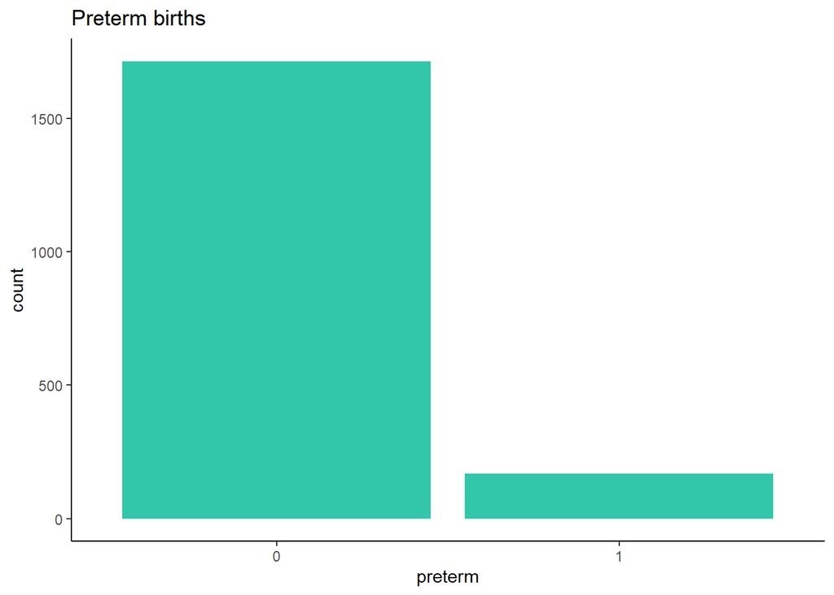

```r
ggplot(Preterm,aes(preterm))+
  geom_bar(fill="#32C7A9")+
  labs(title = 'Preterm births')+
  theme_classic()
```

## education

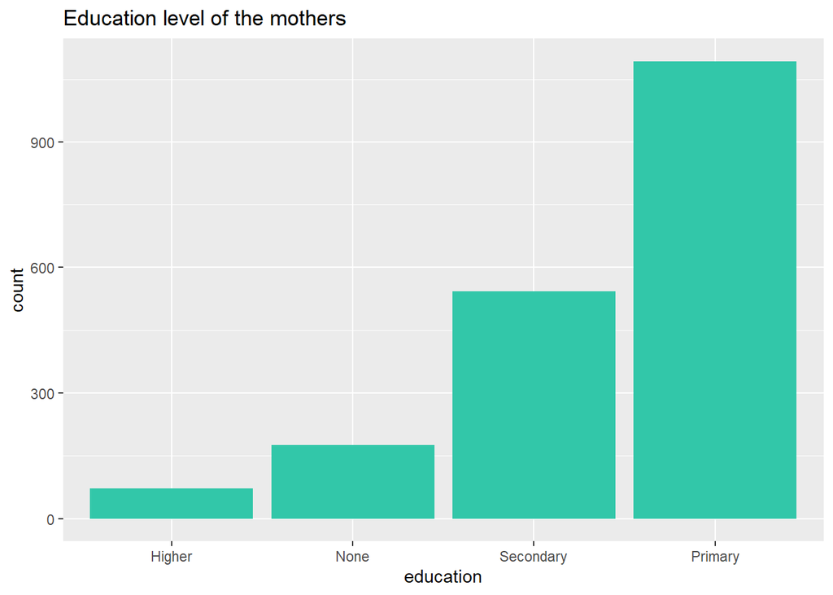

```r
Preterm%>%
  group_by(education)%>%
  summarize(count=n())%>%
ggplot(aes(x = reorder(education,count), y = count))+
  geom_bar(stat="identity", fill="#32C7A9")+
  labs(x='education', title = 'Education level of the mothers')
```

## place.of.anc

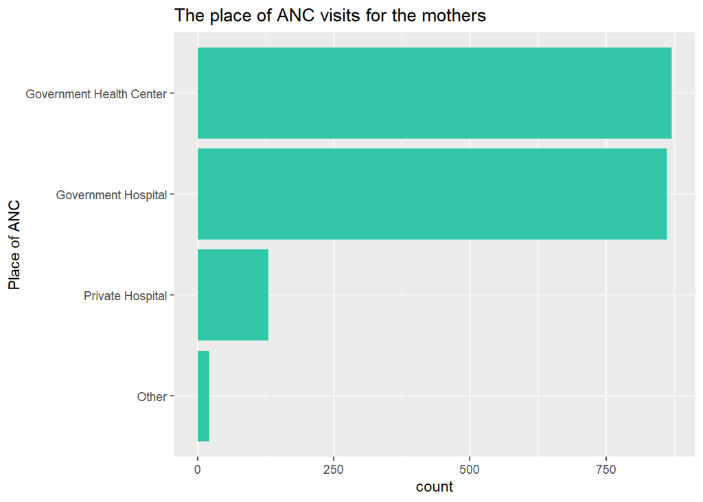

```r
Preterm%>%
  group_by(place.of.anc)%>%
  summarize(count=n())%>%
ggplot(aes(x = reorder(place.of.anc,count), y = count))+
  geom_bar(stat="identity", fill="#32C7A9")+
  coord_flip()+
  labs(x='Place of ANC', title = 'The place of ANC visits for the mothers')
```

**Most mothers attended ANC at Government Health Center or Government Hospital.**

## anc.attendant

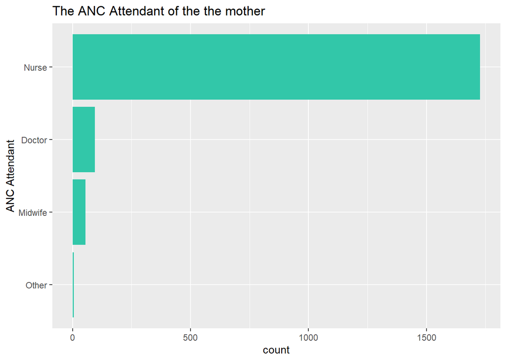

```r
Preterm%>%
  group_by(anc.attendant)%>%
  summarize(count=n())%>%
ggplot(aes(x = reorder(anc.attendant,count), y = count))+
  geom_bar(stat="identity", fill="#32C7A9")+
  coord_flip()+
  labs(x='ANC Attendant', title = 'The ANC Attendant of the the mother')
```

**Majority of the mothers were attended to by a Nurse.**

# Numeric data

## mother’s age

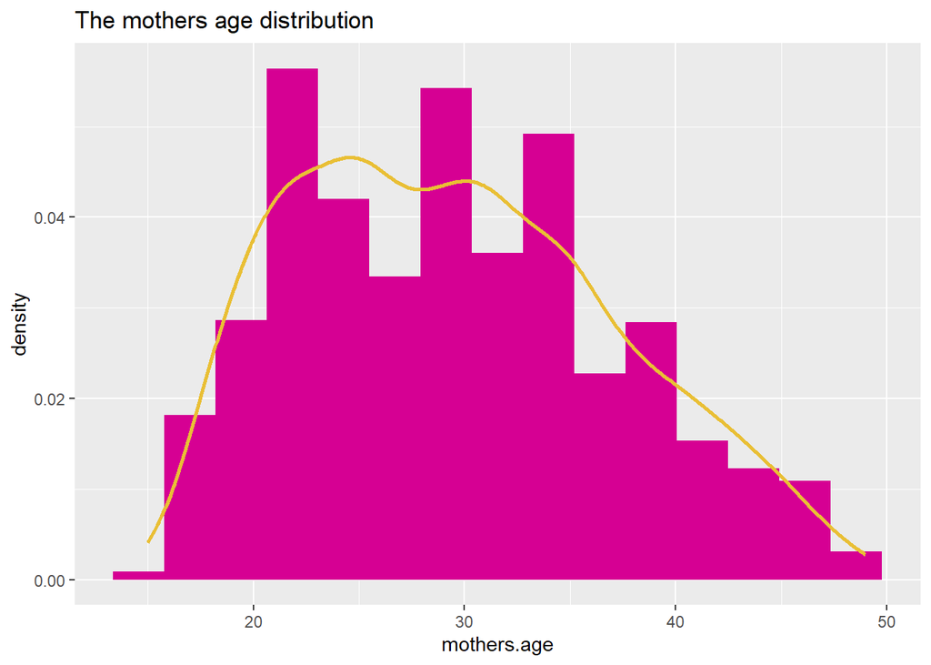

```r
Preterm%>%
  ggplot(aes(mothers.age))+
  geom_histogram(aes(y=after_stat(density)),bins=15, fill="#D60093")+
  geom_density(lwd=1, color="#E9BF35")+
  labs(x='mothers.age', title = 'The mothers age distribution')
```

**The age distribution is right skewed with most mothers between the age of 25 and 35 years.**

## number.of.anc.visits

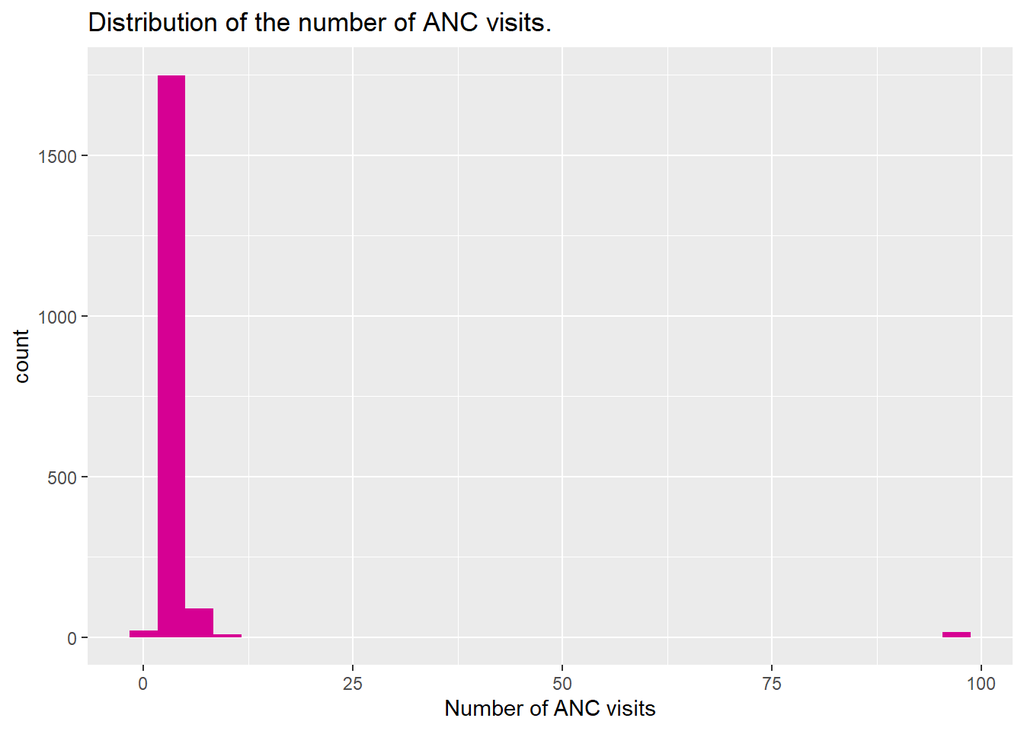

```r
Preterm%>%
  ggplot(aes(number.of.anc.visits))+
  geom_histogram(fill="#D60093")+
  labs(x='Number of ANC visits', title = 'Distribution of the number of ANC visits.')
```

**There are some outliers in the data.**

**Find out how many observations are outliers**

```r
table(Preterm$number.of.anc.visits)
```

```
##
##   1   2   3   4   5   6   7   8   9  10  98
##  20  81 499 912 257  66  13  11   8   1  15
```

**Find out if they are preterm or not**

```r
table(Preterm$number.of.anc.visits,Preterm$preterm)
```

```
##
##        0   1
##   1   17   3
##   2   70  11
##   3  439  60
##   4  838  74
##   5  237  20
##   6   65   1
##   7   13   0
##   8   11   0
##   9    8   0
##   10   1   0
##   98  15   0
```

**The values are all not preterm, so we can just drop them.**

```r
Preterm=Preterm%>%
  filter(!number.of.anc.visits>10)
```

**Plot number.of.anc.visits without the outlier**

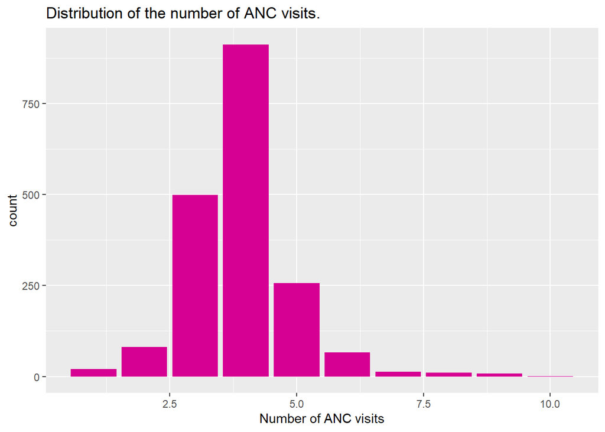

```r
Preterm%>%
  ggplot(aes(number.of.anc.visits))+
  geom_histogram(stat="count", fill="#D60093")+
  labs(x='Number of ANC visits', title = 'Distribution of the number of ANC visits.')
```

**Replace 10 with 9**

```r
Preterm$number.of.anc.visits=ifelse(Preterm$number.of.anc.visits==10,9,Preterm$number.of.anc.visits)
```

**Plot number.of.anc.visits again**

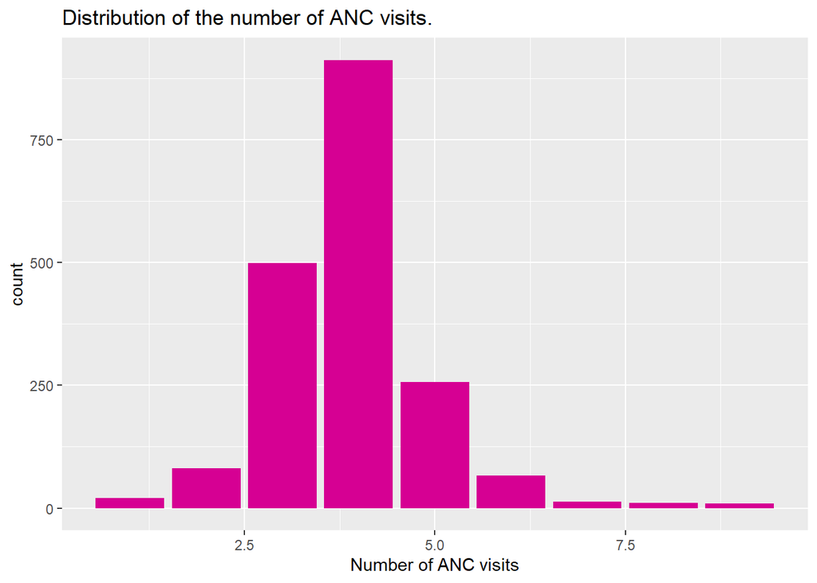

```r
Preterm%>%
  ggplot(aes(number.of.anc.visits))+
  geom_histogram(stat="count", fill="#D60093")+
  labs(x='Number of ANC visits', title = 'Distribution of the number of ANC visits.')
```

**The distribution of the number of ANC visits is right skewed and majority of mothers attended atleast 4 ANC visits.**

## mothers.age VS number.of.anc.visits

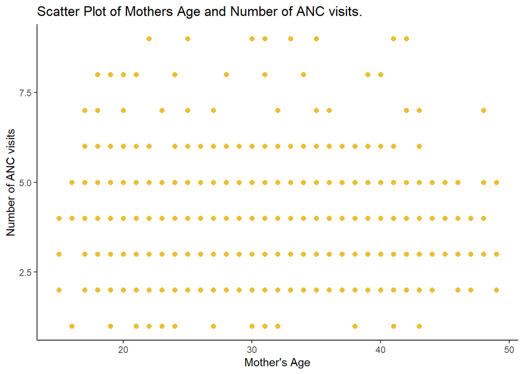

```r
Preterm%>%
  ggplot(aes(mothers.age,number.of.anc.visits))+
  geom_point(color="#E9BF35", size=2)+
  labs(x="Mother's Age", y='Number of ANC visits', title = 'Scatter Plot of Mothers Age and Number of ANC visits.')+
  theme_classic()
```

**There appears to be no linear relationship between mother’s age and the number of anc visits she makes.**

# compare mother’s age with other categorical variables

## education

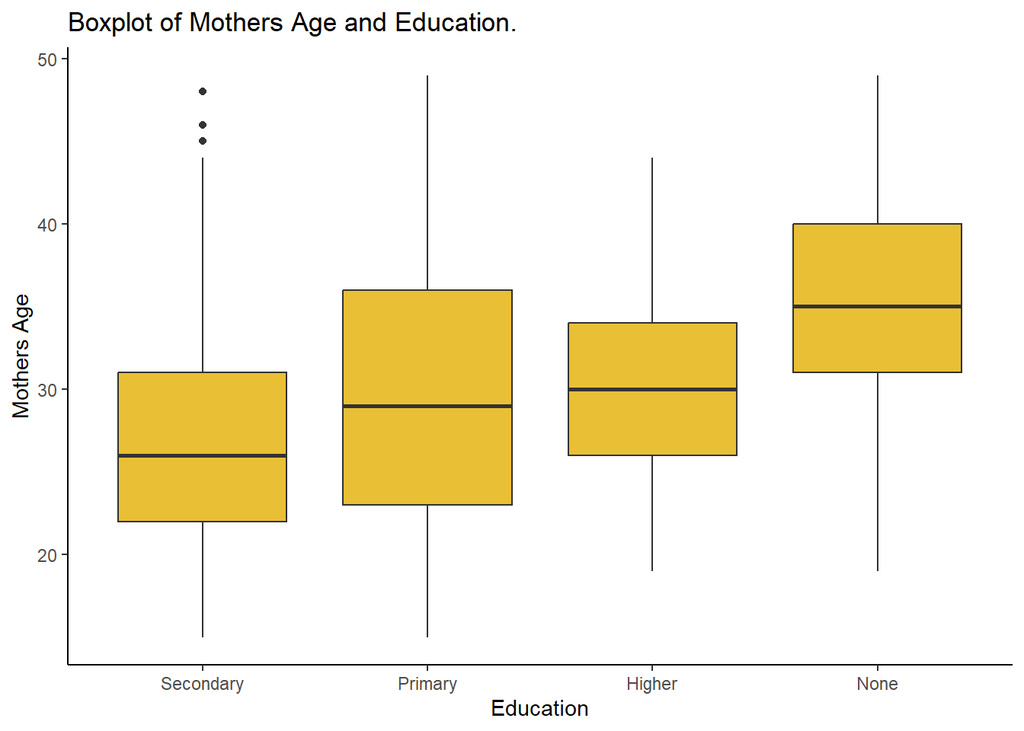

```r
Preterm%>%
  ggplot(aes(reorder(education,mothers.age),mothers.age))+
  geom_boxplot(fill="#E9BF35")+
  labs(x="Education", y='Mothers Age', title = 'Boxplot of Mothers Age and Education.')+
  theme_classic()
```

## ethinicity

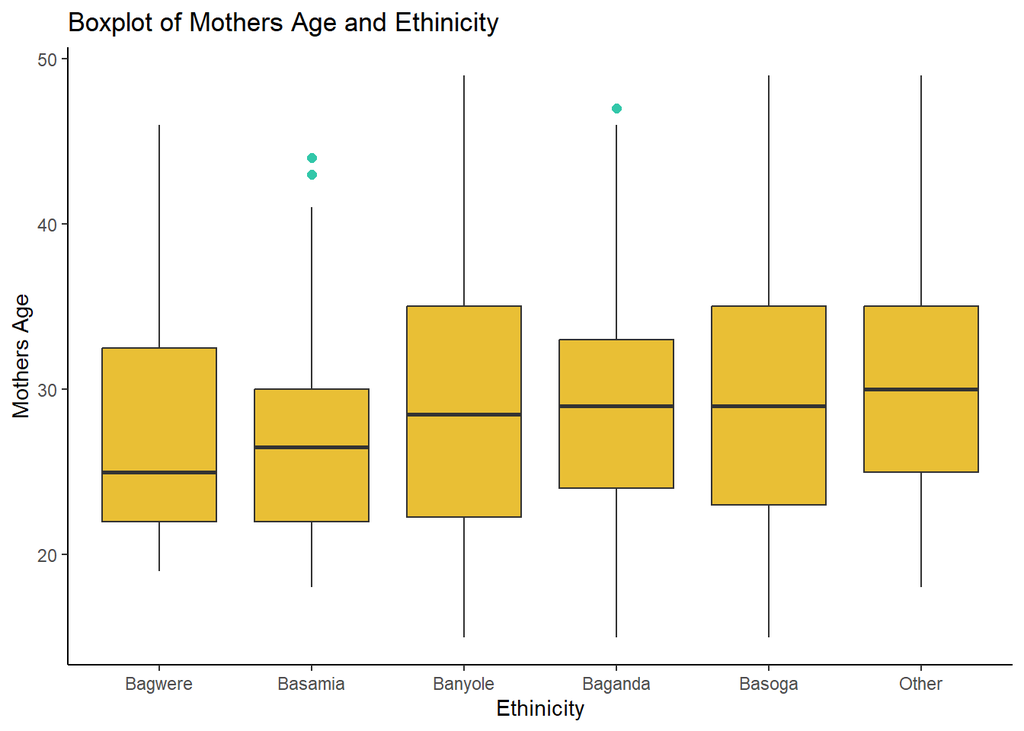

```r
Preterm%>%
  ggplot(aes(reorder(ethinicity,mothers.age,median),mothers.age))+
  geom_boxplot(fill="#E9BF35", outlier.color= "#32C7A9",
               outlier.size =2 )+
   labs(x="Ethinicity", y='Mothers Age', title = 'Boxplot of Mothers Age and Ethinicity')+
  theme_classic()
```

## anc.attendant

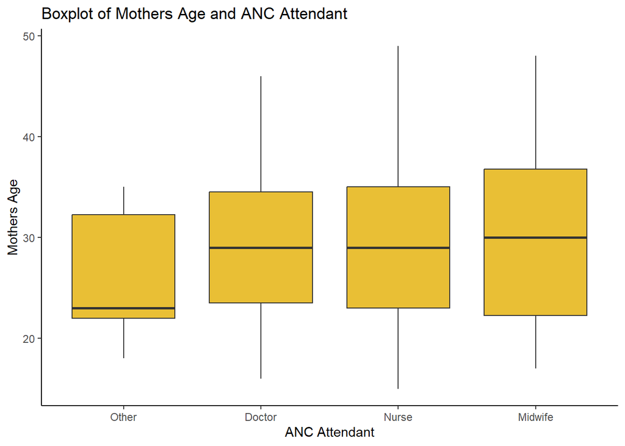

```r
Preterm%>%
  ggplot(aes(reorder(anc.attendant,mothers.age,median),mothers.age))+
  geom_boxplot(fill="#E9BF35")+
   labs(x="ANC Attendant", y='Mothers Age', title = 'Boxplot of Mothers Age and ANC Attendant')+
  theme_classic()
```

## place.of.anc

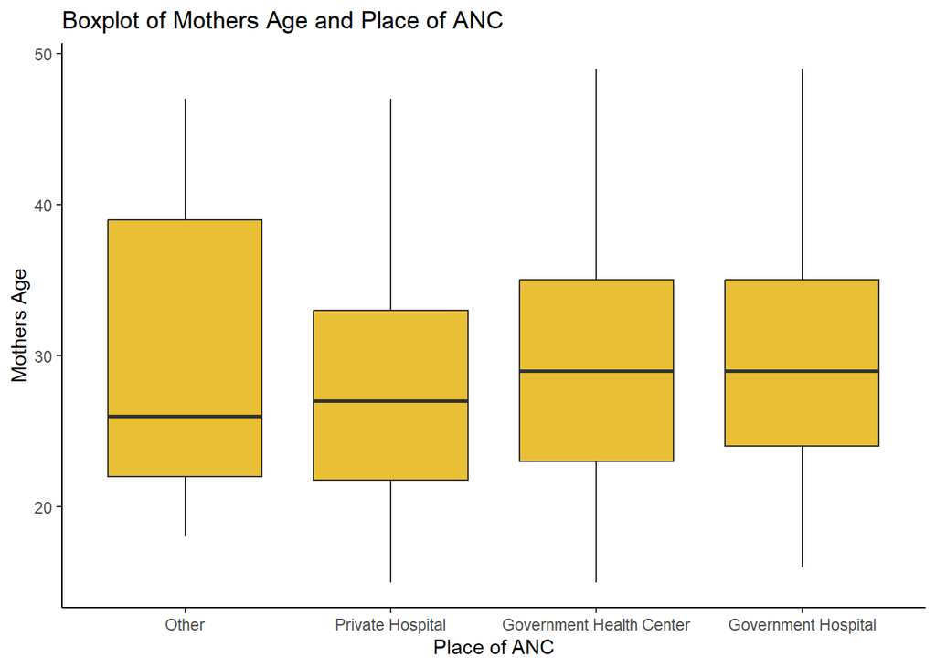

```r
Preterm%>%
  ggplot(aes(reorder(place.of.anc,mothers.age,median),mothers.age))+
  geom_boxplot(fill="#E9BF35")+
   labs(x="Place of ANC", y='Mothers Age', title = 'Boxplot of Mothers Age and Place of ANC')+
  theme_classic()
```

## preterm

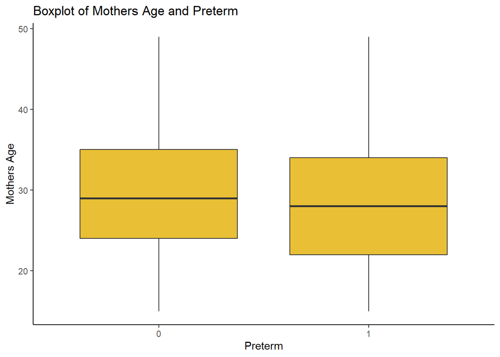

```r
Preterm%>%
  ggplot(aes(reorder(preterm,-mothers.age,median),mothers.age))+
  geom_boxplot(fill="#E9BF35")+
   labs(x="Preterm", y='Mothers Age', title = 'Boxplot of Mothers Age and Preterm')+
  theme_classic()
```

**The median age of mothers who had preterm delivery(1) was lower than that of mothers who did not have preterm delivery(0).**

# Build a machine learning model

```r
require(randomForest)
require(caret)
```

## Divide into Train and Test datasets

```r
set.seed(1234)
pre <- sample(2, nrow(Preterm),replace = TRUE,prob = c(0.7,0.3))
Train <- Preterm[pre==1,]
Test <- Preterm[pre==2,]
```

## Random Forest

```r
rf=randomForest(preterm~mothers.age+education+religion+ethinicity+number.of.anc.visits+anc.attendant+place.of.anc, Preterm)
```

## predict the preterm using the Test dataset

```r
preterm.predicted=predict(rf,Test)
```

## View Predicted values

```r
preterm.predicted
```

```
##   1   2   3   4   5   6   7   8   9  10  11  12  13  14  15  16  17  18  19  20
##   0   0   0   0   0   0   0   0   0   0   0   0   0   0   0   0   0   1   0   0
##  21  22  23  24  25  26  27  28  29  30  31  32  33  34  35  36  37  38  39  40
##   0   0   0   0   0   0   0   0   0   0   0   0   0   0   0   0   0   0   0   0
##  41  42  43  44  45  46  47  48  49  50  51  52  53  54  55  56  57  58  59  60
##   0   0   0   0   0   0   0   0   0   0   0   0   0   0   0   0   0   0   0   0
##  61  62  63  64  65  66  67  68  69  70  71  72  73  74  75  76  77  78  79  80
##   0   0   0   0   0   0   0   0   0   0   0   0   0   0   0   0   0   0   0   0
##  81  82  83  84  85  86  87  88  89  90  91  92  93  94  95  96  97  98  99 100
##   0   0   0   0   0   0   0   0   0   0   0   0   0   0   0   1   0   0   0   0
## 101 102 103 104 105 106 107 108 109 110 111 112 113 114 115 116 117 118 119 120
##   0   0   0   0   0   0   1   0   0   0   0   0   0   0   0   0   0   0   0   0
## 121 122 123 124 125 126 127 128 129 130 131 132 133 134 135 136 137 138 139 140
##   0   0   0   0   0   0   0   0   0   0   0   0   0   0   0   0   0   0   0   0
## 141 142 143 144 145 146 147 148 149 150 151 152 153 154 155 156 157 158 159 160
```

[output cut: 40 more lines]

## model performance

```r
Trf <- table(PredictedValue=preterm.predicted, ActualValue=Test$preterm)
print(confusionMatrix(Trf))
```

```
## Confusion Matrix and Statistics
##
##               ActualValue
## PredictedValue   0   1
##              0 485  35
##              1   0  10
##
##                Accuracy : 0.934
##                  95% CI : (0.9094, 0.9536)
##     No Information Rate : 0.9151
##     P-Value [Acc > NIR] : 0.06554
##
##                   Kappa : 0.3434
##
##  Mcnemar's Test P-Value : 9.081e-09
##
##             Sensitivity : 1.0000
##             Specificity : 0.2222
##          Pos Pred Value : 0.9327
##          Neg Pred Value : 1.0000
##              Prevalence : 0.9151
##          Detection Rate : 0.9151
##    Detection Prevalence : 0.9811
##       Balanced Accuracy : 0.6111
##
##        'Positive' Class : 0
##
```

# Model improvement

**I will now adjust the parameters of the model and rerun the model and see if there is any improvement.**

```r
rf2=randomForest(preterm~mothers.age+education+religion+ethinicity+number.of.anc.visits+anc.attendant+place.of.anc, Preterm, ntree=500, mtry=3, nodesize=0.01*nrow(Test))
```

## predict the preterm using the Test dataset

```r
preterm.predicted2=predict(rf2,Test)
```

## view Predicted values

```r
preterm.predicted2
```

```
##   1   2   3   4   5   6   7   8   9  10  11  12  13  14  15  16  17  18  19  20
##   0   0   0   0   0   0   0   0   0   0   0   0   0   0   0   0   0   1   0   0
##  21  22  23  24  25  26  27  28  29  30  31  32  33  34  35  36  37  38  39  40
##   0   0   0   0   0   0   0   0   0   0   0   0   0   0   0   0   0   0   0   0
##  41  42  43  44  45  46  47  48  49  50  51  52  53  54  55  56  57  58  59  60
##   0   0   0   0   0   0   0   0   0   0   0   0   0   0   0   0   0   0   0   0
##  61  62  63  64  65  66  67  68  69  70  71  72  73  74  75  76  77  78  79  80
##   0   0   0   0   0   0   0   0   0   0   0   0   0   0   0   0   0   0   0   0
##  81  82  83  84  85  86  87  88  89  90  91  92  93  94  95  96  97  98  99 100
##   0   0   0   0   0   0   0   0   0   0   0   0   0   0   0   0   0   0   0   0
## 101 102 103 104 105 106 107 108 109 110 111 112 113 114 115 116 117 118 119 120
##   0   0   0   0   0   0   1   0   0   0   0   0   0   0   0   0   0   0   0   0
## 121 122 123 124 125 126 127 128 129 130 131 132 133 134 135 136 137 138 139 140
##   0   0   0   0   0   0   0   0   0   0   0   0   0   0   0   0   0   0   0   0
## 141 142 143 144 145 146 147 148 149 150 151 152 153 154 155 156 157 158 159 160
```

[output cut: 40 more lines]

## model performance

```r
Trf2 <- table(PredictedValue=preterm.predicted2,
              ActualValue=Test$preterm)
print(confusionMatrix(Trf2))
```

```
## Confusion Matrix and Statistics
##
##               ActualValue
## PredictedValue   0   1
##              0 485  41
##              1   0   4
##
##                Accuracy : 0.9226
##                  95% CI : (0.8965, 0.9439)
##     No Information Rate : 0.9151
##     P-Value [Acc > NIR] : 0.298
##
##                   Kappa : 0.1515
##
##  Mcnemar's Test P-Value : 4.185e-10
##
##             Sensitivity : 1.00000
##             Specificity : 0.08889
##          Pos Pred Value : 0.92205
##          Neg Pred Value : 1.00000
##              Prevalence : 0.91509
##          Detection Rate : 0.91509
##    Detection Prevalence : 0.99245
##       Balanced Accuracy : 0.54444
##
##        'Positive' Class : 0
##
```

# variable importance

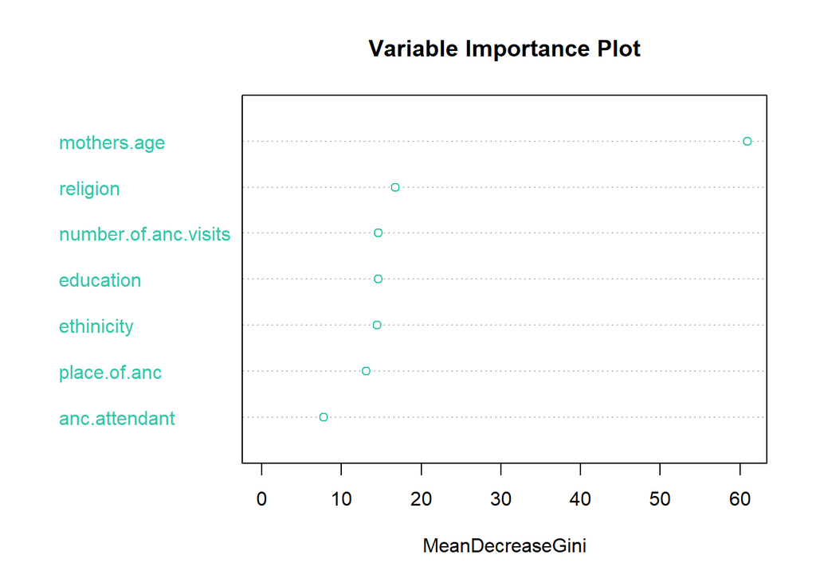

```r
varImpPlot(rf2, main = "Variable Importance Plot", col="#32C7A9")
```

**The mother’s age was the most important variable in predicting preterm birth;this was followed by religion, education, number.of.anc.visits and ethinicity as the top five predictors of preterm birth.**

**place.of.anc and anc.attendant were least important predictors of preterm delivery.**

# Conclusion

**The Random forest model here gives us the mother’s age as a key determinant of preterm birth.**

# Recommendation

**Based on this finding; I suggest that policy makers design programs that are focused on addressing the age specific needs of the mothers in rural communities.**